# An Exploratory Analysis of Bitcoin

Error 404: Group Not Found

April 7, 2019

# Introduction

*Cryptocurrency is a digital currency designed to work as a medium of exchange that uses strong cryptography to secure financial transactions, control the creation of additional units, and verify the transfer of assets. Bitcoin is the first and currently the most widely used and known type of digital currency with a total value of $89.085 billion and over 17.6 million total Bitcoins in circulation. Major world currencies are prone to many challenges that affect their value and purchasing power. With Bitcoin, these challenges are less since no government or country controls the unit. Predicting the future price of Bitcoin, can help potential investors and miners identify the benefits or risks involved with trading, investing and mining bitcoins. To begin with our analysis, we first explore the trends and factors affecting the price of Bitcoin.*

Loading the required libraries and dataset:

```r
require(tidyverse)
require(lattice)
require(dplyr)
sample_btc <- read_csv("bitcoin_dataset.csv")
```

# Data

*The data used is “Cryptocurrency Historical Prices by Sudalairajkumar”, sourced from Kaggle consisting of 2920 rows of information pertaining to the various attributes of Bitcoin transactions collected daily from 2010 through 2018. Our dataset comprises of 24 variables out of which we will be focusing on a few important variables, namely:*

*Date : Date of observation*

*btc_market_price : Average USD market price across major Bitcoin exchanges.*

*btc_total_bitcoins : The total number of Bitcoins that have already been mined.*

*btc_market_cap : The total USD value of Bitcoin supply in circulation.*

*btc_avg_block_size : The average block size in MB.*

*btc_n_transactions : The number of daily confirmed Bitcoin transactions.*

*btc_n_transactions_total : Total number of transactions.*

*btc_cost_per_transaction : miners revenue divided by the number of transactions.*

*btc_hash_rate : The estimated number of tera hashes per second the Bitcoin network is performing.*

*btc_difficulty : A relative measure of how difficult it is to find a new block.*

Sample Data:

```r
head(sample_btc)
```

```
## # A tibble: 6 x 24
##   Date                btc_market_price btc_total_bitco~ btc_market_cap
##   <dttm>                         <dbl>            <dbl>          <dbl>
## 1 2010-02-23 00:00:00                0          2110700              0
## 2 2010-02-24 00:00:00                0          2120200              0
## 3 2010-02-25 00:00:00                0          2127600              0
## 4 2010-02-26 00:00:00                0          2136100              0
## 5 2010-02-27 00:00:00                0          2144750              0
## 6 2010-02-28 00:00:00                0          2152850              0
## # ... with 20 more variables: btc_trade_volume <dbl>,
## #   btc_blocks_size <dbl>, btc_avg_block_size <dbl>,
## #   btc_n_orphaned_blocks <dbl>, btc_n_transactions_per_block <dbl>,
## #   btc_median_confirmation_time <dbl>, btc_hash_rate <dbl>,
## #   btc_difficulty <dbl>, btc_miners_revenue <dbl>,
## #   btc_transaction_fees <dbl>, btc_cost_per_transaction_percent <dbl>,
## #   btc_cost_per_transaction <dbl>, btc_n_unique_addresses <dbl>,
## #   btc_n_transactions <dbl>, btc_n_transactions_total <dbl>,
## #   btc_n_transactions_excluding_popular <dbl>,
## #   btc_n_transactions_excluding_chains_longer_than_100 <dbl>,
## #   btc_output_volume <dbl>, btc_estimated_transaction_volume <dbl>,
## #   btc_estimated_transaction_volume_usd <dbl>
```

# Data Cleaning:

*By observing the imported data, we find a few N/A values i.e missing data.*

```r
summary(sample_btc)
```

```
##       Date                     btc_market_price    btc_total_bitcoins
##  Min.   :2010-02-23 00:00:00   Min.   :    0.000   Min.   : 2110700
##  1st Qu.:2012-02-22 18:00:00   1st Qu.:    6.769   1st Qu.: 8405100
##  Median :2014-02-21 12:00:00   Median :  236.310   Median :12429100
##  Mean   :2014-02-21 12:00:00   Mean   :  897.486   Mean   :11520514
##  3rd Qu.:2016-02-21 06:00:00   3rd Qu.:  603.909   3rd Qu.:15237638
##  Max.   :2018-02-20 00:00:00   Max.   :19498.683   Max.   :16876825
##
##  btc_market_cap      btc_trade_volume    btc_blocks_size
##  Min.   :0.000e+00   Min.   :0.000e+00   Min.   :     0.0
##  1st Qu.:5.561e+07   1st Qu.:2.994e+05   1st Qu.:   777.2
##  Median :3.365e+09   Median :1.024e+07   Median : 15132.0
##  Mean   :1.443e+10   Mean   :8.231e+07   Mean   : 36058.4
##  3rd Qu.:8.210e+09   3rd Qu.:2.935e+07   3rd Qu.: 59301.8
##  Max.   :3.265e+11   Max.   :5.352e+09   Max.   :157665.0
##                      NA's   :21
##  btc_avg_block_size  btc_n_orphaned_blocks btc_n_transactions_per_block
##  Min.   :0.0002163   Min.   :0.0000        Min.   :   1.0
##  1st Qu.:0.0245947   1st Qu.:0.0000        1st Qu.:  55.0
##  Median :0.1998064   Median :0.0000        Median : 378.5
##  Mean   :0.3557330   Mean   :0.3623        Mean   : 677.0
##  3rd Qu.:0.6880359   3rd Qu.:0.0000        3rd Qu.:1238.6
##  Max.   :1.1103268   Max.   :7.0000        Max.   :2722.6
##
##  btc_median_confirmation_time btc_hash_rate      btc_difficulty
##  Min.   : 0.000               Min.   :       0   Min.   :3.000e+00
##  1st Qu.: 6.129               1st Qu.:      12   1st Qu.:1.618e+06
##  Median : 7.933               Median :   26406   Median :3.130e+09
##  Mean   : 7.547               Mean   : 1387725   Mean   :1.808e+11
##  3rd Qu.:10.238               3rd Qu.: 1097174   3rd Qu.:1.584e+11
##  Max.   :47.733               Max.   :25579249   Max.   :2.968e+12
##
##  btc_miners_revenue btc_transaction_fees btc_cost_per_transaction_percent
##  Min.   :       0   Min.   :   0.000     Min.   :    0.14
##  1st Qu.:   47694   1st Qu.:   9.724     1st Qu.:    1.18
##  Median :  889558   Median :  21.119     Median :    2.46
##  Mean   : 2298116   Mean   :  60.907     Mean   :   58.08
##  3rd Qu.: 1865030   3rd Qu.:  50.779     3rd Qu.:    5.84
##  Max.   :53191582   Max.   :1495.947     Max.   :88571.43
##
```

[output cut: 17 more lines]

```
##  Min.   :   118                                      Min.   :    6150
##  1st Qu.:  6889                                      1st Qu.:  497532
##  Median : 35670                                      Median : 1118162
##  Mean   : 63770                                      Mean   : 1568570
##  3rd Qu.:114920                                      3rd Qu.: 2028524
##  Max.   :318896                                      Max.   :45992223
##
##  btc_estimated_transaction_volume btc_estimated_transaction_volume_usd
##  Min.   :      7                  Min.   :0.000e+00
##  1st Qu.:  96609                  1st Qu.:9.890e+05
##  Median : 178741                  Median :3.899e+07
##  Mean   : 203826                  Mean   :2.118e+08
##  3rd Qu.: 258724                  3rd Qu.:1.370e+08
##  Max.   :5825066                  Max.   :5.760e+09
##
```

*A few outliers are also present in the data.*

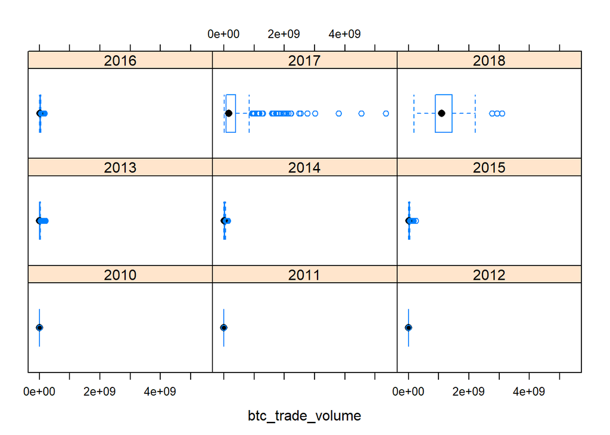

```r
bwplot(~btc_trade_volume | format(as.Date(Date, format="%Y/%m/%d"),"%Y"), data=sample_btc)
```

*Due to the effect of extreme outliers, median value has been chosen to replace the N/A values instead of the mean value.*

```r
sample_btc=sample_btc %>%mutate(btc_trade_volume=replace_na(btc_trade_volume, median(btc_trade_volume, na.rm = TRUE)))
summary(sample_btc)
```

```
##       Date                     btc_market_price    btc_total_bitcoins
##  Min.   :2010-02-23 00:00:00   Min.   :    0.000   Min.   : 2110700
##  1st Qu.:2012-02-22 18:00:00   1st Qu.:    6.769   1st Qu.: 8405100
##  Median :2014-02-21 12:00:00   Median :  236.310   Median :12429100
##  Mean   :2014-02-21 12:00:00   Mean   :  897.486   Mean   :11520514
##  3rd Qu.:2016-02-21 06:00:00   3rd Qu.:  603.909   3rd Qu.:15237638
##  Max.   :2018-02-20 00:00:00   Max.   :19498.683   Max.   :16876825
##  btc_market_cap      btc_trade_volume    btc_blocks_size
##  Min.   :0.000e+00   Min.   :0.000e+00   Min.   :     0.0
##  1st Qu.:5.561e+07   1st Qu.:3.019e+05   1st Qu.:   777.2
##  Median :3.365e+09   Median :1.024e+07   Median : 15132.0
##  Mean   :1.443e+10   Mean   :8.179e+07   Mean   : 36058.4
##  3rd Qu.:8.210e+09   3rd Qu.:2.904e+07   3rd Qu.: 59301.8
##  Max.   :3.265e+11   Max.   :5.352e+09   Max.   :157665.0
##  btc_avg_block_size  btc_n_orphaned_blocks btc_n_transactions_per_block
##  Min.   :0.0002163   Min.   :0.0000        Min.   :   1.0
##  1st Qu.:0.0245947   1st Qu.:0.0000        1st Qu.:  55.0
##  Median :0.1998064   Median :0.0000        Median : 378.5
##  Mean   :0.3557330   Mean   :0.3623        Mean   : 677.0
##  3rd Qu.:0.6880359   3rd Qu.:0.0000        3rd Qu.:1238.6
##  Max.   :1.1103268   Max.   :7.0000        Max.   :2722.6
##  btc_median_confirmation_time btc_hash_rate      btc_difficulty
##  Min.   : 0.000               Min.   :       0   Min.   :3.000e+00
##  1st Qu.: 6.129               1st Qu.:      12   1st Qu.:1.618e+06
##  Median : 7.933               Median :   26406   Median :3.130e+09
##  Mean   : 7.547               Mean   : 1387725   Mean   :1.808e+11
##  3rd Qu.:10.238               3rd Qu.: 1097174   3rd Qu.:1.584e+11
##  Max.   :47.733               Max.   :25579249   Max.   :2.968e+12
##  btc_miners_revenue btc_transaction_fees btc_cost_per_transaction_percent
##  Min.   :       0   Min.   :   0.000     Min.   :    0.14
##  1st Qu.:   47694   1st Qu.:   9.724     1st Qu.:    1.18
##  Median :  889558   Median :  21.119     Median :    2.46
##  Mean   : 2298116   Mean   :  60.907     Mean   :   58.08
##  3rd Qu.: 1865030   3rd Qu.:  50.779     3rd Qu.:    5.84
##  Max.   :53191582   Max.   :1495.947     Max.   :88571.43
##  btc_cost_per_transaction btc_n_unique_addresses btc_n_transactions
##  Min.   :  0.000          Min.   :    110        Min.   :   118
##  1st Qu.:  4.221          1st Qu.:  17190        1st Qu.:  8157
##  Median :  7.866          Median : 132537        Median : 63006
##  Mean   : 15.238          Mean   : 195961        Mean   :102923
```

[output cut: 8 more lines]

```
##  Max.   :300576632        Max.   :470650
##  btc_n_transactions_excluding_chains_longer_than_100 btc_output_volume
##  Min.   :   118                                      Min.   :    6150
##  1st Qu.:  6889                                      1st Qu.:  497532
##  Median : 35670                                      Median : 1118162
##  Mean   : 63770                                      Mean   : 1568570
##  3rd Qu.:114920                                      3rd Qu.: 2028524
##  Max.   :318896                                      Max.   :45992223
##  btc_estimated_transaction_volume btc_estimated_transaction_volume_usd
##  Min.   :      7                  Min.   :0.000e+00
##  1st Qu.:  96609                  1st Qu.:9.890e+05
##  Median : 178741                  Median :3.899e+07
##  Mean   : 203826                  Mean   :2.118e+08
##  3rd Qu.: 258724                  3rd Qu.:1.370e+08
##  Max.   :5825066                  Max.   :5.760e+09
```

*Also, since there are very few observations recorded in the dataset from the year 2010 to 2012, we shall be only considering data from 2012 through 2018 for our analysis.*

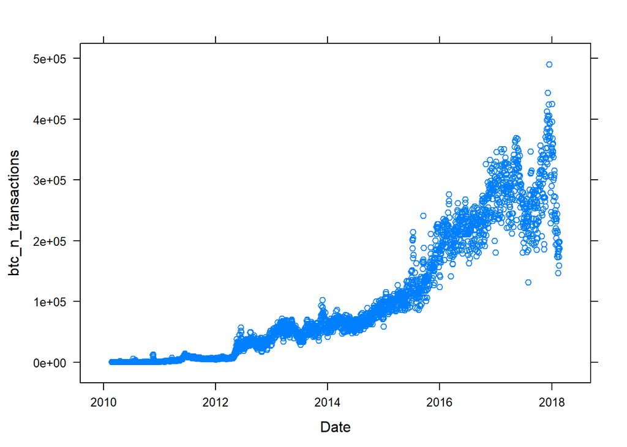

```r
xyplot(btc_n_transactions~Date, data=sample_btc)
```

Filtering the data from year 2012 onwards:

```r
sample_btc1 <- subset(sample_btc, format(as.Date(Date),"%Y")>=2012)
head(sample_btc1)
```

```
## # A tibble: 6 x 24
##   Date                btc_market_price btc_total_bitco~ btc_market_cap
##   <dttm>                         <dbl>            <dbl>          <dbl>
## 1 2012-01-01 00:00:00             5.2           8007500      41639000
## 2 2012-01-02 00:00:00             5.50          8015100      44082248.
## 3 2012-01-03 00:00:00             5.29          8023200      42442728
## 4 2012-01-04 00:00:00             5.61          8030900      45023635.
## 5 2012-01-05 00:00:00             6.40          8038250      51436762.
## 6 2012-01-06 00:00:00             7.22          8046750      58097535
## # ... with 20 more variables: btc_trade_volume <dbl>,
## #   btc_blocks_size <dbl>, btc_avg_block_size <dbl>,
## #   btc_n_orphaned_blocks <dbl>, btc_n_transactions_per_block <dbl>,
## #   btc_median_confirmation_time <dbl>, btc_hash_rate <dbl>,
## #   btc_difficulty <dbl>, btc_miners_revenue <dbl>,
## #   btc_transaction_fees <dbl>, btc_cost_per_transaction_percent <dbl>,
## #   btc_cost_per_transaction <dbl>, btc_n_unique_addresses <dbl>,
## #   btc_n_transactions <dbl>, btc_n_transactions_total <dbl>,
## #   btc_n_transactions_excluding_popular <dbl>,
## #   btc_n_transactions_excluding_chains_longer_than_100 <dbl>,
## #   btc_output_volume <dbl>, btc_estimated_transaction_volume <dbl>,
## #   btc_estimated_transaction_volume_usd <dbl>
```

# Descriptive Statistics:

*On reviewing the data, we find that the least market price of Bitcoin is 4.33 on 02/19/2012 and highest market price is 19498.683 on 12/16/2017. The total number of Bitcoins that have been mined so far is 16876825 as of the last record of the dataset which is 02/20/2018. The highest total USD value of Bitcoin supply in circulation is 3.270e+11 and the average block size is 0.46067 MB. A summary of the key statistics of the data is given below:*

```r
summary(sample_btc1)
```

```
##       Date                     btc_market_price    btc_total_bitcoins
##  Min.   :2012-01-01 00:00:00   Min.   :    4.333   Min.   : 8007500
##  1st Qu.:2013-07-14 12:00:00   1st Qu.:  117.785   1st Qu.:11416188
##  Median :2015-01-26 00:00:00   Median :  385.450   Median :13764525
##  Mean   :2015-01-26 00:00:00   Mean   : 1167.377   Mean   :13431441
##  3rd Qu.:2016-08-08 12:00:00   3rd Qu.:  686.930   3rd Qu.:15805075
##  Max.   :2018-02-20 00:00:00   Max.   :19498.683   Max.   :16876825
##  btc_market_cap      btc_trade_volume    btc_blocks_size
##  Min.   :3.630e+07   Min.   :8.034e+04   Min.   :   633
##  1st Qu.:1.325e+09   1st Qu.:4.372e+06   1st Qu.:  8962
##  Median :5.512e+09   Median :1.638e+07   Median : 29167
##  Mean   :1.878e+10   Mean   :1.064e+08   Mean   : 46903
##  3rd Qu.:1.019e+10   3rd Qu.:4.026e+07   3rd Qu.: 78438
##  Max.   :3.265e+11   Max.   :5.352e+09   Max.   :157665
##  btc_avg_block_size btc_n_orphaned_blocks btc_n_transactions_per_block
##  Min.   :0.01518    Min.   :0.0000        Min.   :  33.0
##  1st Qu.:0.15189    1st Qu.:0.0000        1st Qu.: 314.0
##  Median :0.35860    Median :0.0000        Median : 634.0
##  Mean   :0.46067    Mean   :0.4717        Mean   : 875.5
##  3rd Qu.:0.79473    3rd Qu.:1.0000        3rd Qu.:1473.0
##  Max.   :1.11033    Max.   :7.0000        Max.   :2722.6
##  btc_median_confirmation_time btc_hash_rate      btc_difficulty
##  Min.   : 4.583               Min.   :       8   Min.   :1.160e+06
##  1st Qu.: 7.475               1st Qu.:     214   1st Qu.:2.616e+07
##  Median : 8.583               Median :  311208   Median :4.397e+10
##  Mean   : 9.643               Mean   : 1806578   Mean   :2.354e+11
##  3rd Qu.:11.167               3rd Qu.: 1580610   3rd Qu.:2.135e+11
##  Max.   :47.733               Max.   :25579249   Max.   :2.968e+12
##  btc_miners_revenue btc_transaction_fees btc_cost_per_transaction_percent
##  Min.   :   28400   Min.   :   2.449     Min.   : 0.3246
##  1st Qu.:  512314   1st Qu.:  14.745     1st Qu.: 1.0480
##  Median : 1264052   Median :  30.822     Median : 1.7401
##  Mean   : 2983209   Mean   :  77.896     Mean   : 2.4067
##  3rd Qu.: 2272129   3rd Qu.:  65.812     3rd Qu.: 3.2398
##  Max.   :53191582   Max.   :1495.947     Max.   :13.1099
##  btc_cost_per_transaction btc_n_unique_addresses btc_n_transactions
##  Min.   :  0.7657         Min.   :   7701        Min.   :  4523
##  1st Qu.:  5.9933         1st Qu.:  60953        1st Qu.: 52831
##  Median :  8.7861         Median : 199310        Median : 91203
##  Mean   : 18.3356         Mean   : 253364        Mean   :133062
```

[output cut: 8 more lines]

```
##  Max.   :300576632        Max.   :470650
##  btc_n_transactions_excluding_chains_longer_than_100 btc_output_volume
##  Min.   :  4523                                      Min.   :  244251
##  1st Qu.: 25439                                      1st Qu.:  829198
##  Median : 49292                                      Median : 1416401
##  Mean   : 82245                                      Mean   : 1899412
##  3rd Qu.:139400                                      3rd Qu.: 2250798
##  Max.   :318896                                      Max.   :45992223
##  btc_estimated_transaction_volume btc_estimated_transaction_volume_usd
##  Min.   : 39199                   Min.   :3.530e+05
##  1st Qu.:149319                   1st Qu.:2.061e+07
##  Median :209072                   Median :6.224e+07
##  Mean   :220748                   Mean   :2.756e+08
##  3rd Qu.:275926                   3rd Qu.:1.783e+08
##  Max.   :931548                   Max.   :5.760e+09
```

```r
sample_btc1 %>% group_by(format(as.Date(Date, format="%Y/%m/%d"),"%Y"))%>%summarise(Avg_MarketPrice=mean(btc_market_price), Avg_MarketCapital=mean(btc_market_cap))
```

```
## # A tibble: 7 x 3
##   `format(as.Date(Date, format = "%Y/%m/%~ Avg_MarketPrice Avg_MarketCapit~
##   <chr>                                              <dbl>            <dbl>
## 1 2012                                                8.47        81549684.
## 2 2013                                              190.        2235823791.
## 3 2014                                              526.        6768096328.
## 4 2015                                              272.        3920553102.
## 5 2016                                              567.        8926851117.
## 6 2017                                             4001.       66403834218.
## 7 2018                                            11504.      193512134528.
```

# Exploratory Analysis:

## How has the market price of bitcoin changed over the years?

*The Market Price of Bitcoin is the average USD market price of Bitcoin across major Bitcoin exchanges or in simpler terms, the price/value of Bitcoin when sold in a given market. Below is a picturization of how the market value of Bitcoin has changed over the years.*

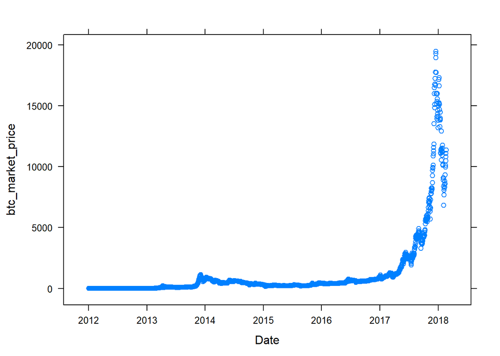

```r
xyplot(btc_market_price~Date, data=sample_btc1)
```

*The graph shows that the market price of Bitcoin has seen a gradual increase over time and hence indicates a rapid rise in the popularity of Bitcoin. This implies, Bitcoin is in high demand as of 2018.*

## How does the limited supply of Bitcoins affect its value?

*The total number of Bitcoins that have already been mined is 16,876,825 as per our data. By the stipulation set forth by the founders of Bitcoin, it has a limited and finite supply. In fact, there are only 21 million Bitcoins that can be mined in total. So, from our data, we’re left with only 4.1 million Bitcoins or approximately 20% of the supply of Bitcoin that will ultimately be made available.*

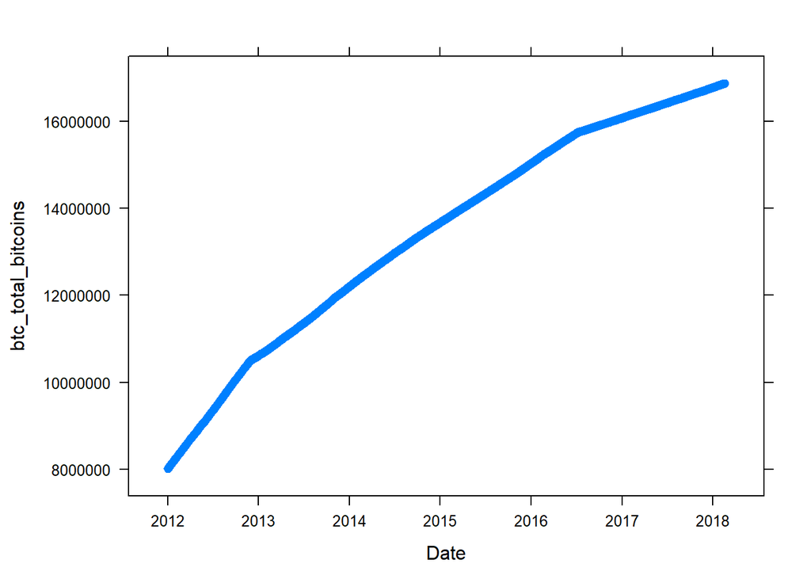

```r
xyplot(btc_total_bitcoins~Date, data=sample_btc1)
```

*Bitcoin has already seen massive hikes in price in 2017 and 2018. While no one is entirely sure how Bitcoin will continue to spread to the larger financial world, it seems likely that a limited supply of the currency may cause prices to continue to increase.*

*The imbalance of supply and demand translates to the high pricing of Bitcoin.*

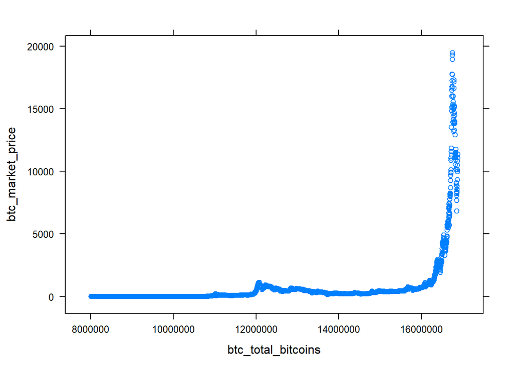

```r
xyplot(btc_market_price~btc_total_bitcoins, data=sample_btc1)
```

## Is average block size and transaction confirmation related to each other? How?

*Bitcoin works on a vast public ledger, also called a blockchain, where all confirmed transactions are included as so-called ‘blocks.’ As each block enters the system, it is broadcast to the peer-to-peer computer network of users for validation. In this way, all users are aware of each transaction, which prevents stealing and double-spending, where someone spends the same currency twice.*

*Transactions, at its most basic level, are made up of data which is usually composed of the information regarding the transaction itself. This data, like any other, takes up space on the block it is included. Currently, each block on the Bitcoin blockchain is able to contain 1 MB of data, meaning that the block size of Bitcoin is 1 megabyte. This means that there is a limit to how many transactions can fit in Bitcoin’s blocks.*

*Consequently, Bitcoin is faced with a scalability problem. 1MB of data size holds an average of 2500 transactions. On average, Bitcoin processes four transactions per second. With more than 200,000 transactions a day, most Bitcoin transactions are delayed for an average of 30 minutes.*

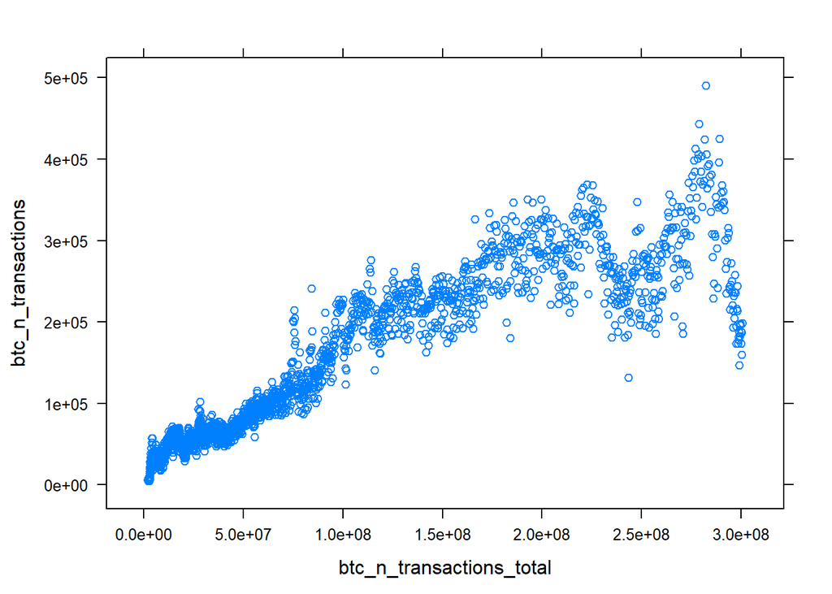

```r
xyplot(btc_n_transactions~btc_n_transactions_total, data=sample_btc1)
```

## How do we speed up transactions?

*Bitcoin transactions are not immediate. When a user wishes to send Bitcoins, information is broadcast from his/her wallet to the (users in the) network, who verify that he/she has enough coins, and that they have never been spent before. Once validated, miners will include this transaction - along with others - in a new block in the blockchain. This is called a transaction confirmation.*

*where:*

*Per_TC = Percent transactions confirmed on bitcoins*

*btc_n_transactions = Number of transactions confirmed on bitcoins*

*btc_n_transactions_total = Total number of transactions performed*

The percentage of transactions per day and from which we can get the average transactions confirmed per year:

```r
sample_btc1 %>% mutate(Per_TC=(btc_n_transactions/btc_n_transactions_total)*100) %>% group_by(format(as.Date(Date, format="%Y/%m/%d"),"%Y")) %>% summarise(Avg_Per_TC=mean(Per_TC))
```

```
## # A tibble: 7 x 2
##   `format(as.Date(Date, format = "%Y/%m/%d"), "%Y")` Avg_Per_TC
##   <chr>                                                   <dbl>
## 1 2012                                                   0.438
## 2 2013                                                   0.287
## 3 2014                                                   0.166
## 4 2015                                                   0.164
## 5 2016                                                   0.163
## 6 2017                                                   0.123
## 7 2018                                                   0.0850
```

*The above table shows that the percentage of transactions confirmed per year is decreasing every year*

*Each time a new block is added to the chain (every ten minutes), the transaction is said to be confirmed again. Bigger block size would mean more transactions being confirmed at once, hence speeding up transaction time.*

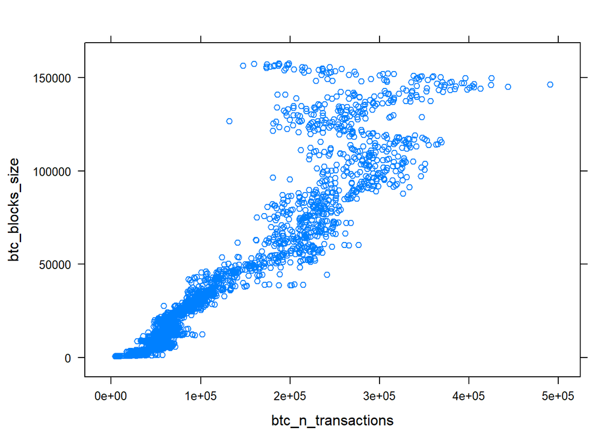

```r
xyplot(btc_blocks_size~btc_n_transactions, data=sample_btc1)
```

## But will increasing block size profit the bitcoin market?

*Bitcoins are acquired by a process called mining. The role of miners is to secure the network and to process every Bitcoin transaction. Miners achieve this by solving a computational problem which allows them to chain together blocks of transactions. For this service, miners are rewarded with newly-created Bitcoins and transaction fees*

*Bitcoin miners are paid per block they produce. They also get the transaction fees paid for all the transactions contained in the block. But with the block size increased, the miner’s fees will go down. Small miners would likely stop mining in the process since they would receive less pay in fees. Large mining companies would take more control of the mining business, which is bad for the network*

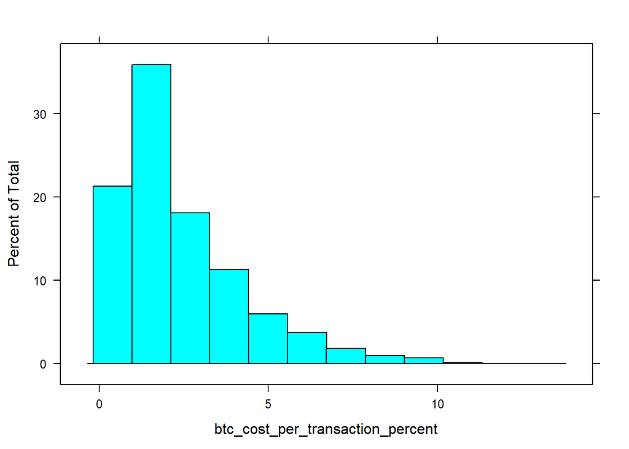

```r
histogram(~btc_cost_per_transaction_percent, data=sample_btc1)
```

## Hash rate and Difficulty level

*The mining process of Bitcoin is connected with the cost of investment in electricity and hardware. When it comes to the price, increase in price can lead the market participants to make an investment in hardware that leads to increased hash rate and in effect higher difficulty of finding a new block.*

*A hash is the output of a hash function and, as it relates to Bitcoin, the Hash Rate is the speed at which a computer is completing an operation in the Bitcoin code*

*Hash Rate and difficulty level of finding a new block of the blockchain have strong linear relation. When the Bitcoin network’s difficulty increases, the hash rate increases and consequently, the miner earns 12.5 Bitcoin and the transaction fees.*

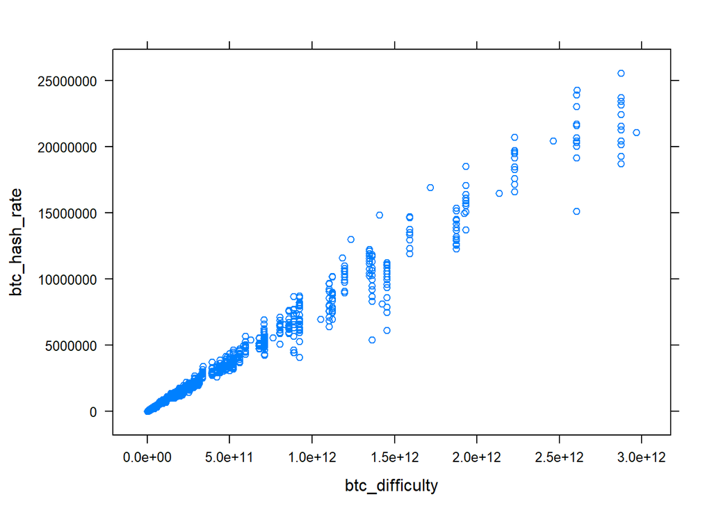

```r
xyplot(btc_hash_rate~btc_difficulty, data=sample_btc1)
```

*If the miners are mining as an alternative to direct investment, they move to Bitcoin purchasers hence increasing the demand for Bitcoin and its price*

# Results and Conclusion

*In this report, we have analyzed the important predictors of Bitcoin price. Through our analysis we have found that the limited supply of Bitcoins has increased its demand, thereby projecting a possibility of higher future price of Bitcoins. On the contrary, increase in average block size could cause a negative impact on the Bitcoin network. Also, higher hash rates can lead to increased mining, thereby carrying the “blockchain” forward and ultimately favoring the Bitcoin market. With the help of these findings, we aim to predict the future price of Bitcoin through the Vector Autoregression prediction model.*